# Social participation and support

[back to Home page |](https://github.com/huiwen-goy/C2-multidomain) [back to Analyses page |](https://huiwen-goy.github.io/C2-multidomain/C2-11Analyses.html) [Data quality |](https://huiwen-goy.github.io/C2-multidomain/C2-1Quality.html)

[Demographics |](https://huiwen-goy.github.io/C2-multidomain/C2-2Demographic.html) [Physical health |](https://huiwen-goy.github.io/C2-multidomain/C2-3Physical.html) [Hearing |](https://huiwen-goy.github.io/C2-multidomain/C2-4Hearing.html) [Cognition |](https://huiwen-goy.github.io/C2-multidomain/C2-5Cognition.html) [Mobility and balance |](https://huiwen-goy.github.io/C2-multidomain/C2-6Mobility.html) [Quality of life |](https://huiwen-goy.github.io/C2-multidomain/C2-7QoL.html) [Mental health |](https://huiwen-goy.github.io/C2-multidomain/C2-8Mental.html) [Social |](https://huiwen-goy.github.io/C2-multidomain/C2-9Social.html) [Views |](https://huiwen-goy.github.io/C2-multidomain/C2-10Views.html)

# Loneliness (CLSA)

back to top

Responses are 4 discrete options, later collapsed into 2 categories for analysis (lonely or not lonely) according to the following: “Participants were classified as lonely if they responded “some of the time” (1 to 2 days), “occasionally” (3 to 4 days), or “all of the time” (5 to 7 days). Those who responded “rarely or never” (<1 day) were considered not lonely.” (Mick et al, 2018)

The hearing group variable is currently binary: “Normal hearing” is BPTA4 ≤ 25 and “HL” is BPTA4 > 25 dB HL.

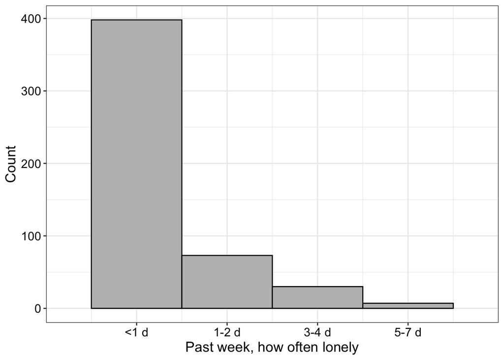

```
##
##          Not lonely Lonely <NA>
##   normal        223     50    8
##   HL            124     37    6
##   <NA>           51     23    5
```

```
##
##  Pearson's Chi-squared test
##
## data:  table(data$BPTA4_group, data$Lonely)
## X-squared = 1.3759, df = 1, p-value = 0.2408
```

# Social Network Index

There are 6 options on how often the participant gets together with various people, ranging from “Within the last day or two” to “More than 1 year ago”, with additional options of “They live in my household” and “Not applicable”.

Following the scoring procedure in Hamalainen et al (2021), 1 point was assigned if participants reported having contact at least every 1–2 weeks for each of the following categories: children, other close family members, friends, neighbors, fellow volunteers, members of nonreligious community groups, members of religious groups. One point was also assigned for being married or in a domestic partnership. The max score was therefore 8 in this study.

Note that in this study, info on marital status was pulled in from the Demographics section, and the point was assigned for the “close family members” category if the participant responded “They live in my household” for children, siblings, or other close relatives. Participants were not asked about work colleagues and schoolmates in this study.

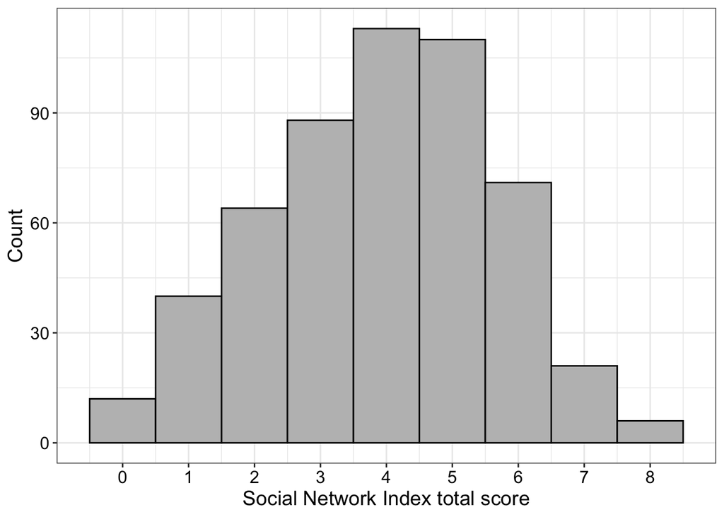

```
##
##  Welch Two Sample t-test
##
## data:  data$Social_network_index by data$BPTA4_group
## t = -1.2261, df = 335.04, p-value = 0.221
## alternative hypothesis: true difference in means between group normal and group HL is not equal to 0
## 95 percent confidence interval:
##  -0.5427148  0.1259399
## sample estimates:
## mean in group normal     mean in group HL
##             3.875445             4.083832
```

# Social participation (CCHS)

back to top

Items consist of 8 different activities, with participation options ranging from “At least once a day” to “Never”. Following Hamalainen et al (2021), social participation is broken down into two measurements: the minimum frequency of participation in any activity, and the number of types of activities participated in at least weekly.

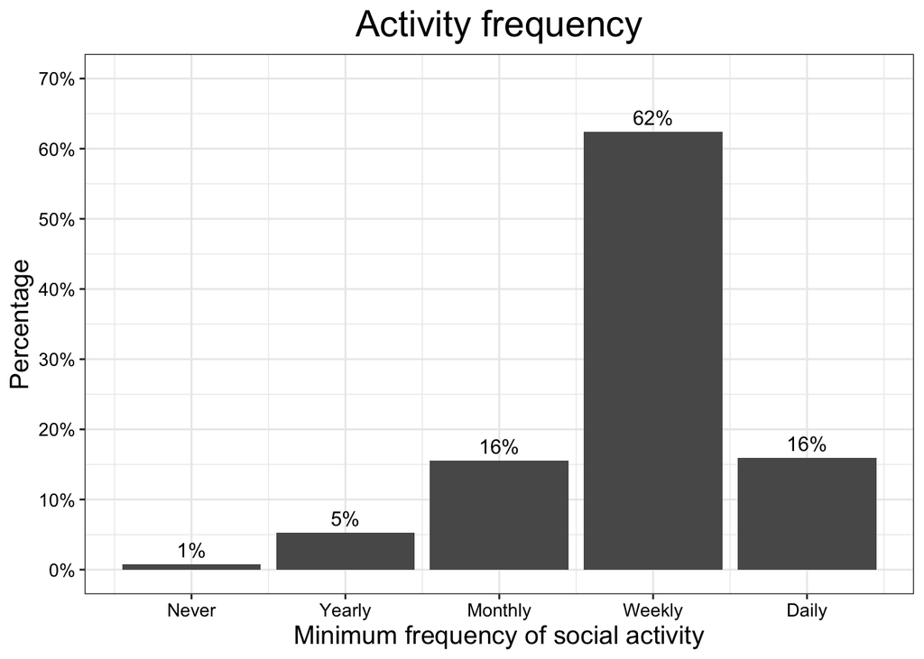

```
##
##  Welch Two Sample t-test
##
## data:  data$Soc_participation_freq by data$BPTA4_group
## t = -1.3229, df = 358.76, p-value = 0.1867
## alternative hypothesis: true difference in means between group normal and group HL is not equal to 0
## 95 percent confidence interval:
##  -0.23879990  0.04673109
## sample estimates:
## mean in group normal     mean in group HL
##             2.879121             2.975155
```

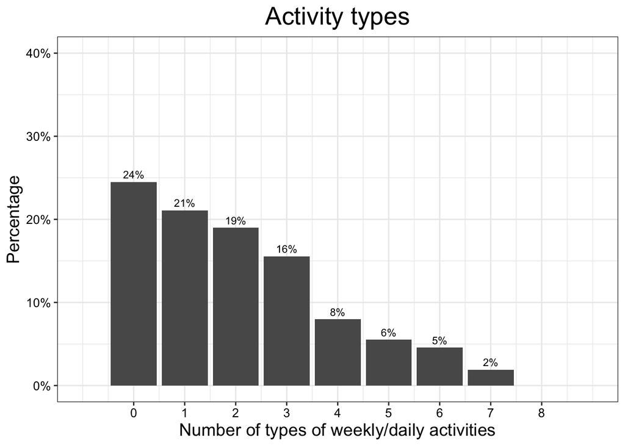

```
##
##  Welch Two Sample t-test
##
## data:  data$Soc_participation_types by data$BPTA4_group
## t = -1.1763, df = 321.32, p-value = 0.2403
## alternative hypothesis: true difference in means between group normal and group HL is not equal to 0
## 95 percent confidence interval:
##  -0.5804849  0.1460654
## sample estimates:
## mean in group normal     mean in group HL
##             2.046263             2.263473
```

# General Relationship Satisfaction

back to top

This scale was only presented to participants who responded that they were “Currently married and living together, or living with someone in a marital-like relationship”. 385 of 527 participants (73%) were presented with this scale.

Responses are discrete options, ranging from 1 (low satisfaction) to 5 (high satisfaction). The overall score is an average of responses, with higher numbers indicating better relationship satisfaction. Two items are reverse-coded.

```
##
##  Welch Two Sample t-test
##
## data:  tempRS$GRS_mean by data$BPTA4_group
## t = -1.5559, df = 229.01, p-value = 0.1211
## alternative hypothesis: true difference in means between group normal and group HL is not equal to 0
## 95 percent confidence interval:
##  -0.3354410  0.0394246
## sample estimates:
## mean in group normal     mean in group HL
##             4.301533             4.449541
```

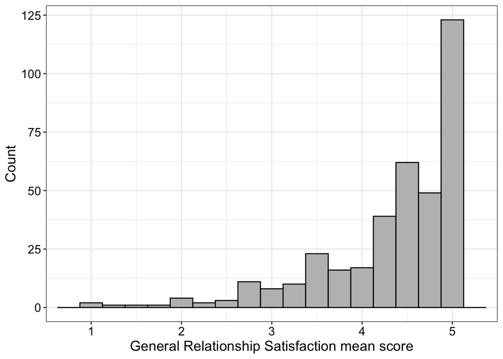

# Social Support (MOS)

back to top

Responses are 5 discrete options, ranging from “None of the time” to “All of the time”, regarding how much support is available if needed. The overall score is an average of responses, with higher numbers indicating more social support. No items are reverse-coded.

There are four subdomains: Emotional/informational support, tangible support, affectionate support, and positive social interactions. The final item on pet ownership is kept separate and does not contribute to the average score.

Source: CLSA main wave v4.0 June 2018

```
##
##  Welch Two Sample t-test
##
## data:  tempMOS$MOS_overall_mean by data$BPTA4_group
## t = 0.94958, df = 306.95, p-value = 0.3431
## alternative hypothesis: true difference in means between group normal and group HL is not equal to 0
## 95 percent confidence interval:
##  -0.08992044  0.25765069
## sample estimates:
## mean in group normal     mean in group HL
##             4.101809             4.017943
```

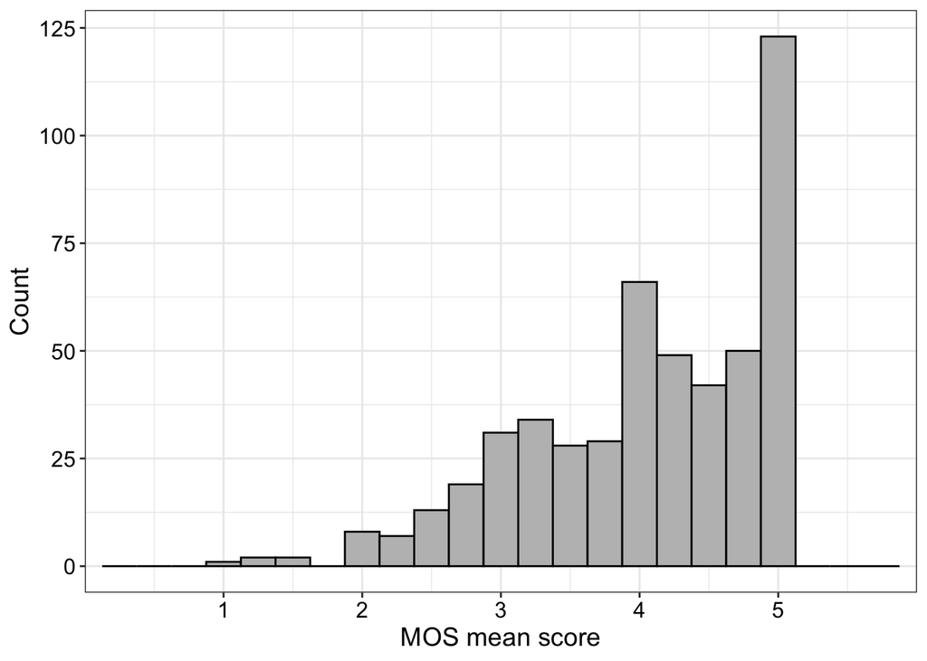

```
## [1] "Emotional/informational support"
```

```
##    Min. 1st Qu.  Median    Mean 3rd Qu.    Max.    NA's
##   1.000   3.500   4.125   4.009   4.875   5.000      23
```

```
## [1] "Tangible support"
```

```
##    Min. 1st Qu.  Median    Mean 3rd Qu.    Max.    NA's
##   1.000   3.500   4.250   4.011   5.000   5.000      23
```

```
## [1] "Affectionate support"
```

```
##    Min. 1st Qu.  Median    Mean 3rd Qu.    Max.    NA's
##   1.000   3.667   4.583   4.192   5.000   5.000      23
```

```
## [1] "Positive social interaction"
```

```
##    Min. 1st Qu.  Median    Mean 3rd Qu.    Max.    NA's
##   1.000   3.500   4.250   4.099   5.000   5.000      23
```

```
##   Pet companion     %
## 1          None 54.84
## 2     Own a pet 40.42
## 3          <NA>  4.74
```

# Other variables available

back to top

- There are 4 domain scores for MOS, besides the overall mean.